# R4ds ch. 3 Data visualization

This script follows the book R4ds by Hadley wickham. Source: https://r4ds.had.co.nz/

```r
#install.packages("tidyverse")
library(tidyverse)
```

3.2 First steps 3.2.1 The mpg data frame

plot mpg dataframe fuel efficiency on highway vs car engine size

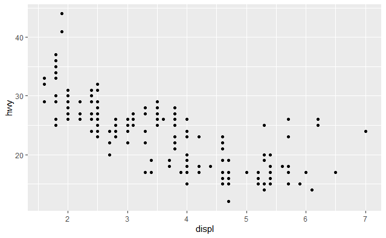

```r
ggplot(data = mpg) +
  geom_point(mapping = aes(x = displ, y = hwy))
```

create ggplot2 template

ggplot(data = ) + (mapping = aes())

3.2.4 Exercises

Q. Run ggplot(data = mpg). What do you see? A. an empty plot

Q. How many rows are in mpg? How many columns? A. 234 rows and 11 columns

Make a scatterplot of hwy vs cyl.

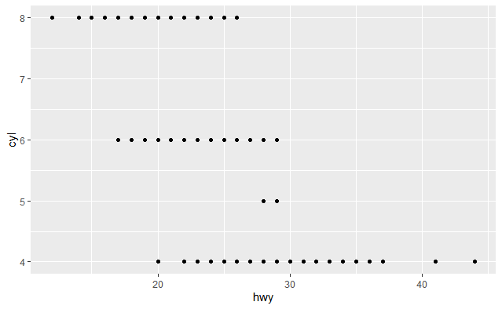

```r
ggplot(data = mpg) +
  geom_point(mapping = aes(x = hwy, y = cyl))
```

Q. What happens if you make a scatterplot of class vs drv? Why is the plot not useful?

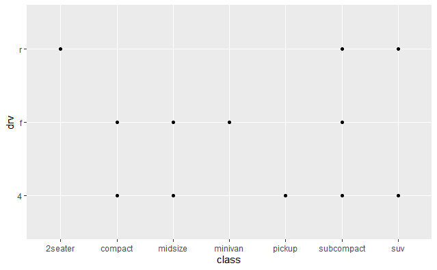

```r
ggplot(data = mpg) +
  geom_point(mapping = aes(x = class, y = drv))
```

3.3 aesthetic mapping

assign a unique color to each car class

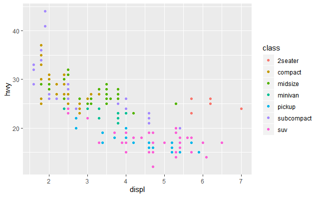

```r
ggplot( data = mpg) +
  geom_point(mapping = aes( x = displ, y = hwy, color = class ))
```

assign different point size for each car class

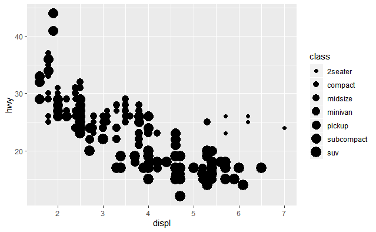

```r
ggplot(data = mpg) +
  geom_point(mapping = aes(x = displ, y = hwy, size = class))
```

same plot with transparent point based on class

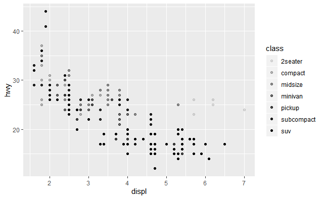

```r
ggplot(data = mpg) +
  geom_point(mapping = aes( x = displ, y = hwy, alpha = class))
```

same plot with different shape for each car class

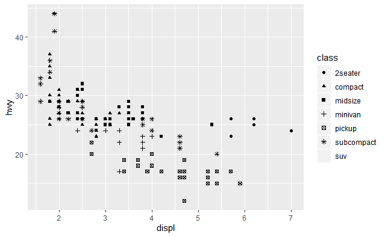

```r
ggplot(data = mpg) +
  geom_point(mapping = aes(x = displ, y = hwy, shape = class))
```

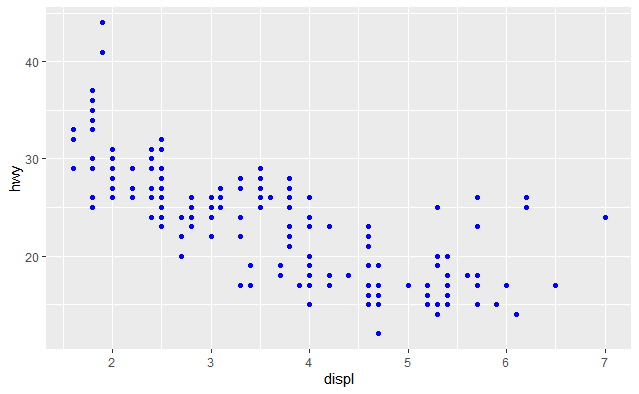

```r
ggplot(data = mpg) +
  geom_point(mapping = aes( x = displ, y = hwy), color = 'blue')
```

3.3.1 exercises

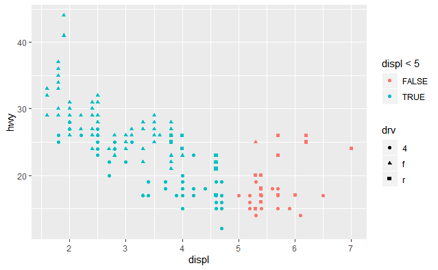

```r
ggplot(data = mpg) +
  geom_point(mapping = aes(x = displ, y =  hwy, color = displ < 5, shape = drv))
```

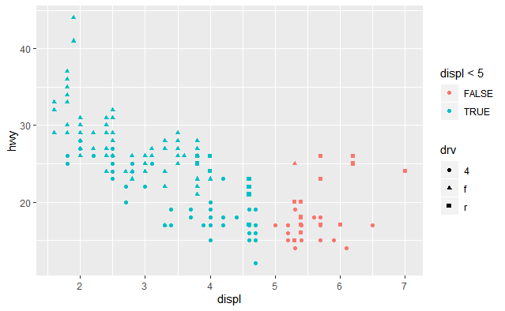

```r
ggplot(data = mpg) +
geom_point(mapping = aes(x = displ, y =  hwy, color = displ < 5, shape = drv))
```

3.5 Facets

create multiple plots for different classes of a single variable with facet

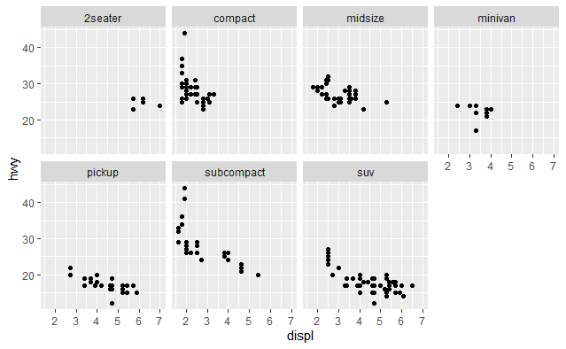

```r
ggplot(data = mpg) +
  geom_point(mapping = aes(x = displ, y = hwy)) +
  facet_wrap(~ class, nrow = 2) # facet wrap needs a discrete variable
```

facet a plot on combination of 2 variables.

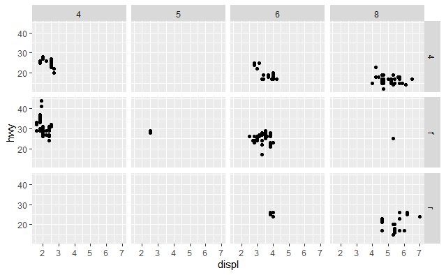

```r
ggplot(data = mpg) +
  geom_point(mapping = aes(x = displ, y = hwy)) +
  facet_grid(drv ~ cyl) # facet grid should contain two variables
```

facet grid: scatter plot between engine displacement (displ), miles per gallon (hwy), sorted by number of cylinders

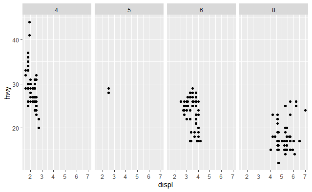

```r
ggplot(data = mpg) +
  geom_point(mapping = aes(x = displ, y = hwy)) +
  facet_grid( . ~ cyl) # use . if you don't want to facet rows or columns
```

3.5.1 Exercises

1. facet wrap using a continious variable splits plots by value

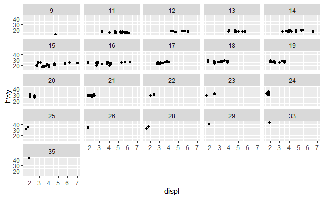

```r
ggplot(data = mpg) +
  geom_point(mapping = aes(x = displ, y = hwy)) +
  facet_wrap(~ cty)
```

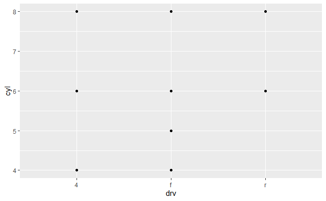

```r
ggplot(data = mpg) +
  geom_point(mapping = aes(x = drv, y = cyl))
```

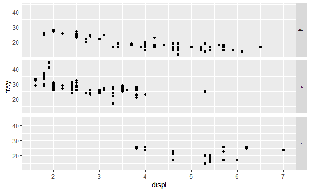

```r
ggplot(data = mpg) +
  geom_point(mapping = aes(x = displ, y = hwy)) +
  facet_grid(drv ~ .)
```

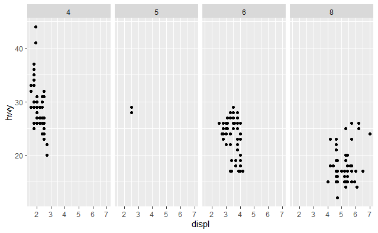

```r
ggplot(data = mpg) +
  geom_point(mapping = aes(x = displ, y = hwy)) +
  facet_grid(. ~ cyl)
```

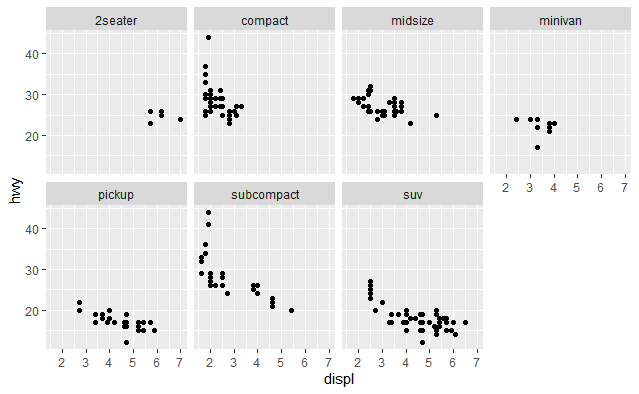

```r
ggplot(data = mpg) +
  geom_point(mapping = aes(x = displ, y = hwy)) +
  facet_wrap(. ~ class, nrow = 2)
```

3.6 Geometric objects

compare geoms. First plot a scatterplot

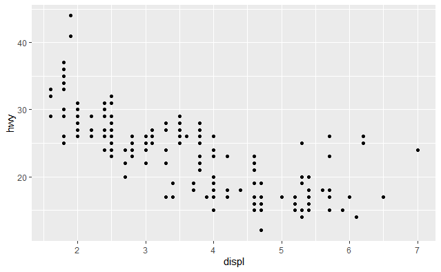

```r
ggplot( data = mpg) +
  geom_point(aes(x = displ, y = hwy))
```

then a smoothed geom scatterplot

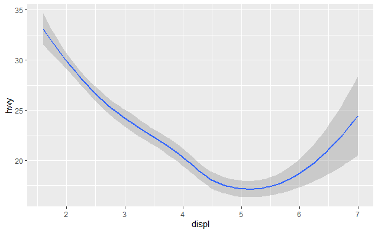

```r
ggplot(data = mpg) +
  geom_smooth(mapping = aes(x  =  displ, y = hwy))
```

separate cars into three lines based on drv value.

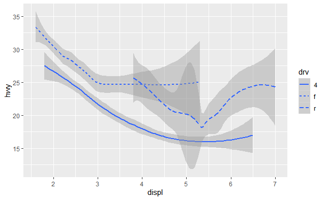

```r
ggplot( data = mpg) +
  geom_smooth(mapping = aes(x = displ, y = hwy, linetype = drv  )) # set linetype for different wheel drive (f = front wheel, 4 = four wheel, r = rear wheel)
```

now overlay smoothed lines and points and separate by drive class (4wheel,rear,front)

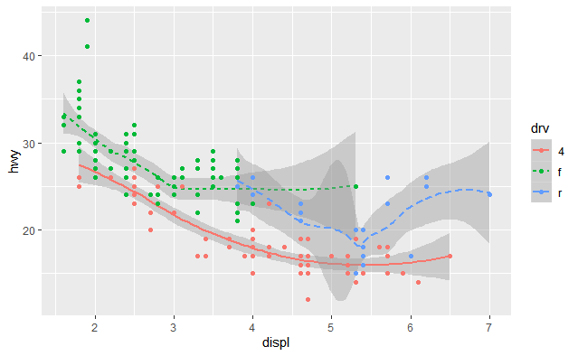

```r
ggplot(data = mpg) +
  geom_smooth(mapping = aes( x = displ, y = hwy, color = drv ,linetype = drv)) +
  geom_point(mapping = aes(x = displ, y = hwy, color = drv))
```

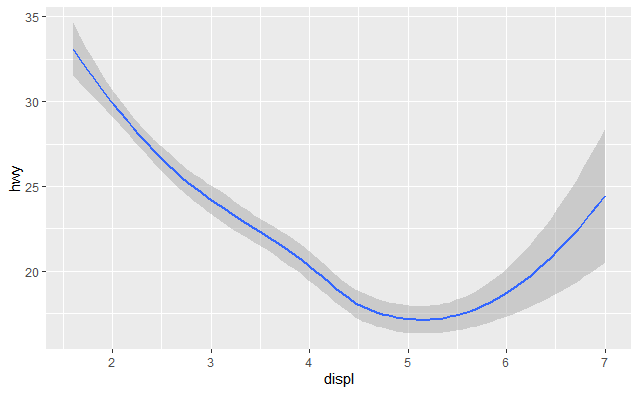

```r
ggplot(data = mpg) +
  geom_smooth(mapping = aes(x = displ, y = hwy))
```

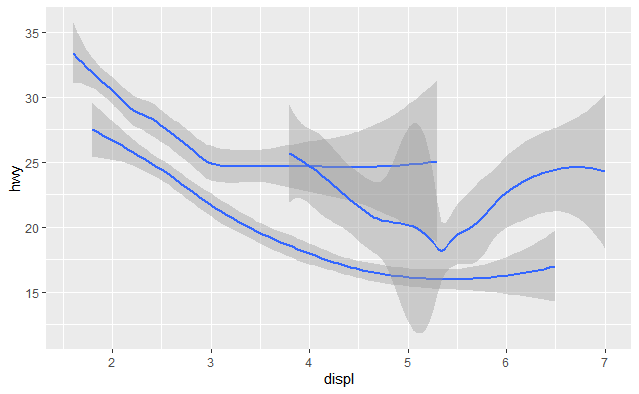

```r
ggplot(data = mpg) +
  geom_smooth(mapping = aes( x = displ, y = hwy, group = drv))
```

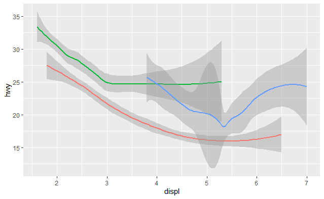

```r
ggplot(data = mpg) +
  geom_smooth(mapping = aes(x = displ, y = hwy, color = drv),
                            show.legend = FALSE)
```

now display multiple geoms in the same plots

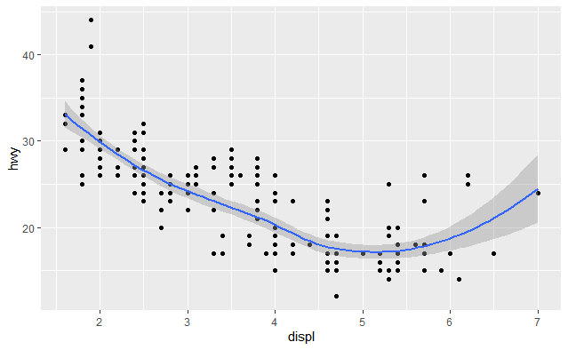

```r
ggplot(data = mpg) +
  geom_point(mapping = aes( x = displ, y = hwy)) + # add scatter plot
  geom_smooth(mapping = aes(x = displ, y = hwy)) # add smooth line
```

now recreate the same plot without code duplication

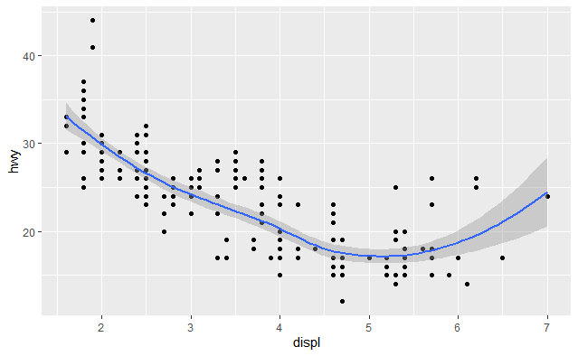

```r
ggplot(data = mpg, mapping = aes( x = displ, y = hwy)) +
  geom_point() +
  geom_smooth()
```

mappings for a geom will change the layout only for that layout. Use global mappings for all geoms

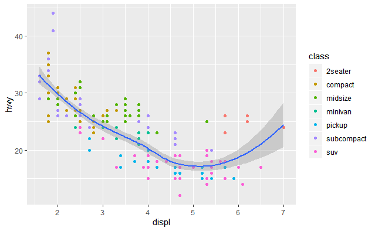

```r
ggplot(data = mpg, mapping = aes( x = displ, y = hwy)) +
  geom_point(mapping = aes(color = class)) +
               geom_smooth()
```

now specify different data for each geom layer. Smoothed geom shows a subset of auto class subcompact

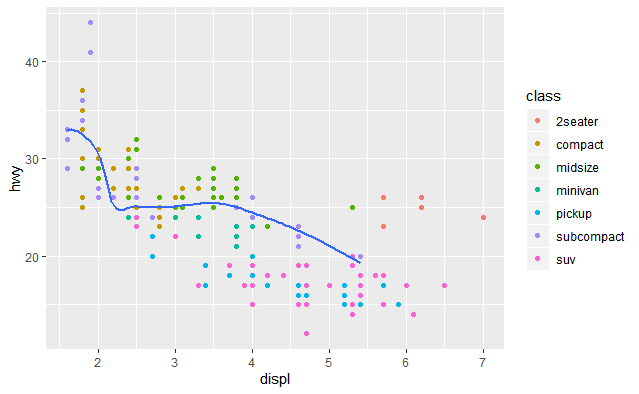

```r
ggplot(data = mpg, mapping = aes( x = displ, y = hwy)) +
  geom_point(mapping = aes( color = class)) +
  geom_smooth(data = filter(mpg , class == "subcompact"),se = F) # se = confidence interval
```

3.6.1 exercises line = geom_line histogram = geom_hist boxplot = geom_boxplot() area chart = geom_area()